# R Notebook

# 1 やりたいこと

得点数をモデリングする - 得点数 = カウントデータ - ポアソン分布でモデリングする方針 - 非負のカウントデータのため

```r
df_stats_1992 <- read_csv('../data/nba/processed/player_stats_1992.csv')
```

```
## ─ Column specification ────────────────────────────
```

```r
data <- df_stats_1992$PTS

# 観測されたデータ数
length(data)
```

```
## [1] 356
```

```r
# データの要約
summary(data)
```

```
##    Min. 1st Qu.  Median    Mean 3rd Qu.    Max.
##     0.0   148.5   492.0   608.2   973.8  2404.0
```

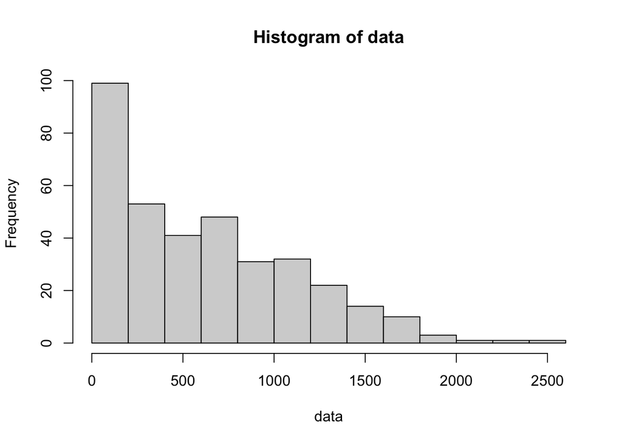

```r
# ヒストグラム
hist(data)
```

```r
# 標本統計量
var(data) # 標本分散
```

```
## [1] 263564.8
```

```r
sd(data) # 標本標準偏差
```

```
## [1] 513.3857
```

```r
sqrt(var(data))
```

```
## [1] 513.3857
```

```r
mean(data) # 標本平均
```

```
## [1] 608.1629
```

カウントデータかつ、平均と標準偏差が近いので、ポアソン分布を見てみる。 どう見てもポアソン分布ではなさそう(平均 = 分散が成り立っていない)だが、一旦は確認のためにポアソン分布を見てみる。

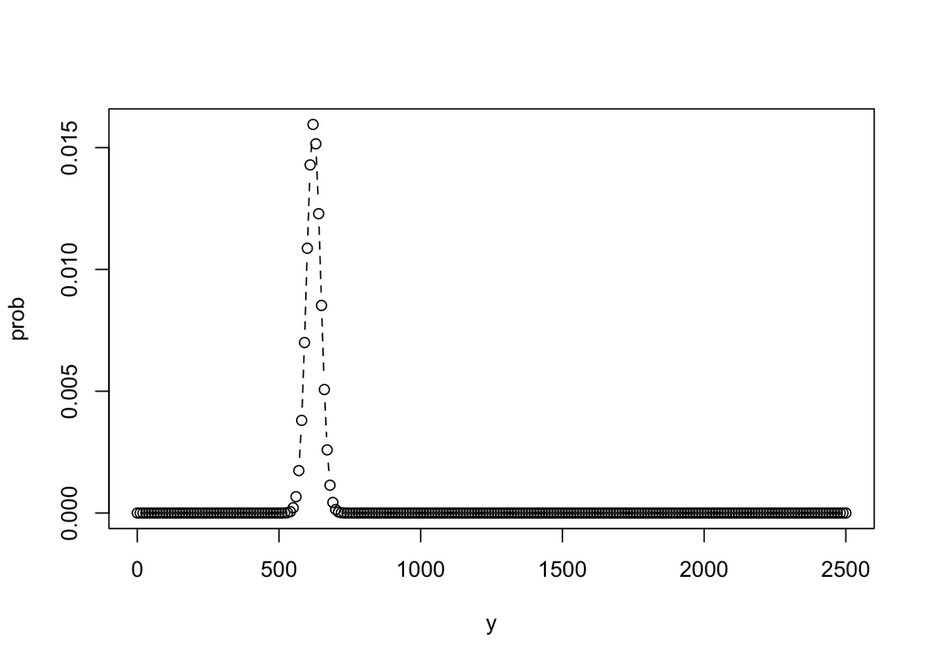

```r
y <- seq(0, 2500, 10)
prob <- dpois(y, lambda = 622.3)

plot(y, prob, type = 'b', lty = 2)
```

やっぱりどう見ても違っている。

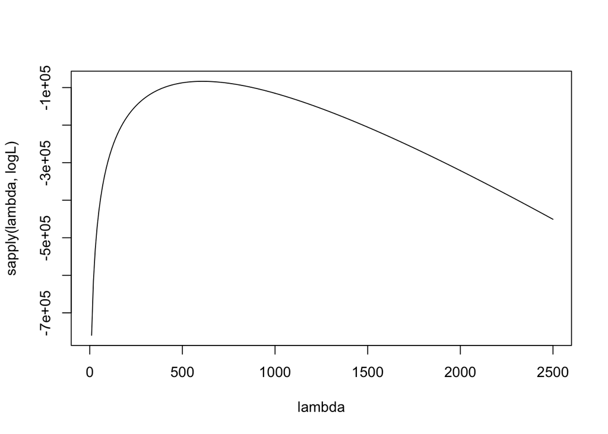

```r
# 対数尤度

logL <- function(m) {
    dpois(data, m, log = TRUE) %>%
    sum()
    }


lambda <- seq(0, 2500, 10)
plot(lambda, sapply(lambda, logL), type='l')
```

# 2 説明できる変数について調べる

今回の得点数は、シーズンの総得点数。 - 明らかに、プレイ時間(MS)が影響すると考えられる。(出場時間が長いほど、得点も大きくなる) - ポジション(ガードの方が戦術的に点を取りやすい?)

```r
data <- df_stats_1992 %>%
    select(player, PTS, MP, pos)

# 文字列を因子型に変換
data <- data %>%
    mutate(pos = factor(pos))

data %>% head()
```

```
## # A tibble: 6 × 4
##   player               PTS    MP pos
##   <chr>              <dbl> <dbl> <fct>
## 1 Alaa Abdelnaby       432   934 PF
## 2 Mahmoud Abdul-Rauf   837  1538 PG
## 3 Mark Acres           208   926 C
## 4 Michael Adams       1408  2795 PG
## 5 Rafael Addison       444  1175 SF
## 6 Mark Aguirre         851  1582 SF
```

```r
# posを見てみる
summary(data)
```

```
##     player               PTS               MP              pos
##  Length:356         Min.   :   0.0   Min.   :   1.0   SG     :77
##  Class :character   1st Qu.: 148.5   1st Qu.: 465.8   C      :75
##  Mode  :character   Median : 492.0   Median :1428.0   PF     :74
##                     Mean   : 608.2   Mean   :1394.2   PG     :64
##                     3rd Qu.: 973.8   3rd Qu.:2220.5   SF     :62
##                     Max.   :2404.0   Max.   :3346.0   SF-SG  : 2
##                                                       (Other): 2
```

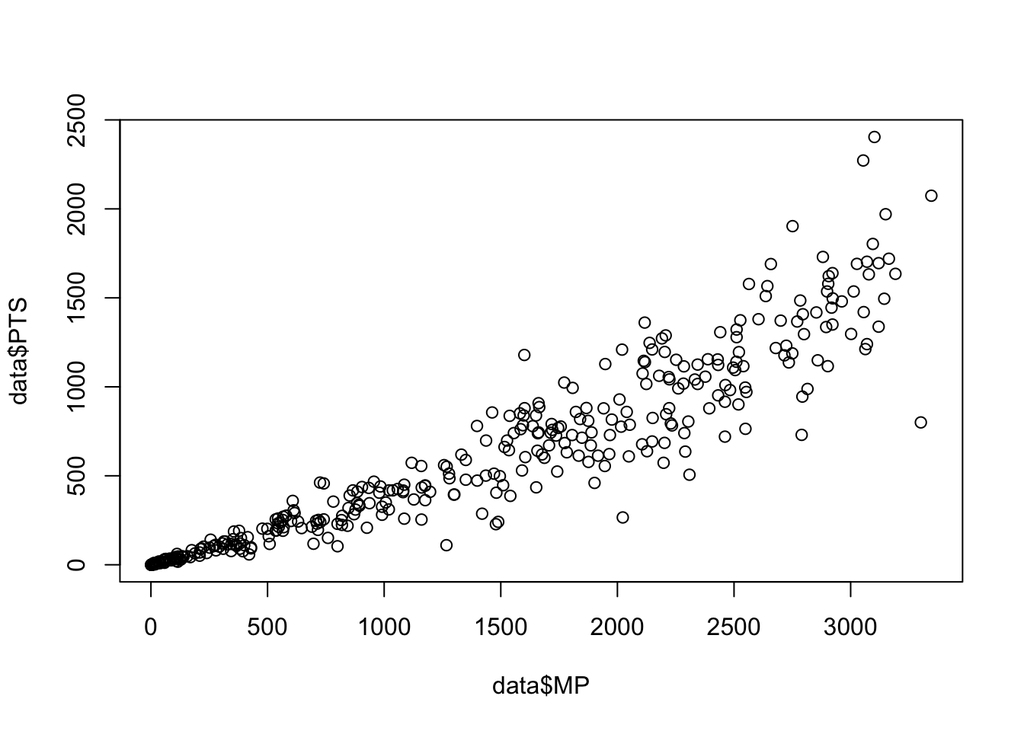

```r
# プロットしてみる
plot(data$MP, data$PTS)
```

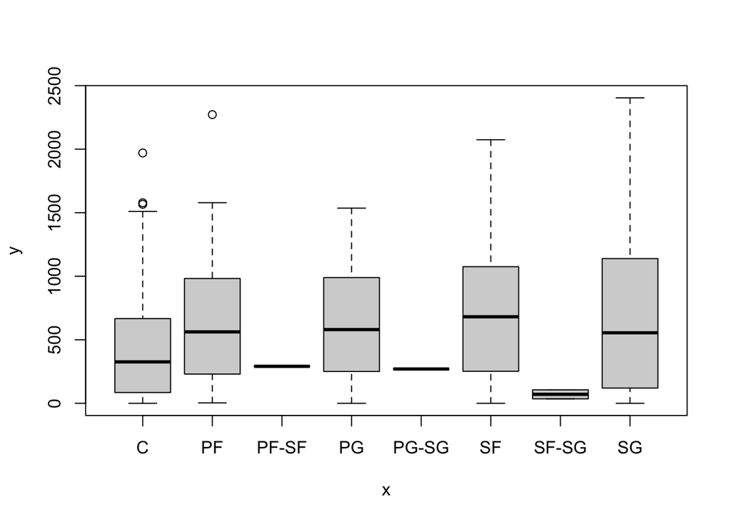

```r
plot(data$pos, data$PTS)
```

複合ポジションが書かれている人はめちゃ少ないので、問題ありそうなので、書き換える。 wikipediaから、ポジションを一つに決める

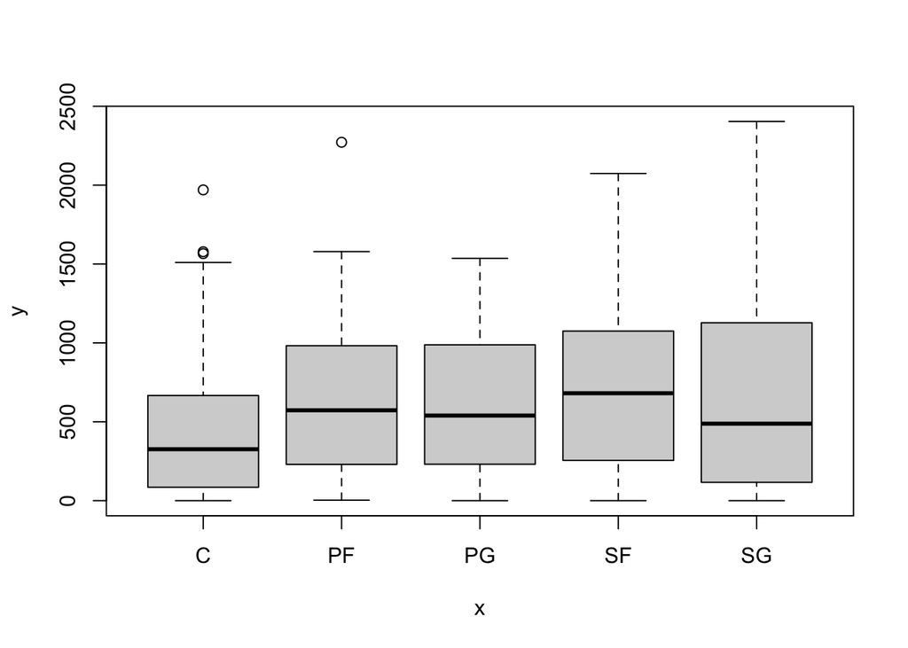

```r
data <- data %>%
    mutate(
        pos = as.character(pos),
        pos = case_when(
            player == 'Sean Higgins' ~'SF',
            player == 'Rex Chapman' ~ 'SG',
            player == 'John Morton' ~ 'PG',
            player == 'Kennard Winchester' ~ 'SG',
            TRUE ~ pos
            ),
        pos = factor(pos)
        )

# プロットしてみる
plot(data$pos, data$PTS)
```

```r
# posのないモデルをあてはめてみる

fit1 <- glm(PTS ~ MP, data = data, family = poisson)

summary(fit1)
```

```
##
## Call:
## glm(formula = PTS ~ MP, family = poisson, data = data)
##
## Deviance Residuals:
##     Min       1Q   Median       3Q      Max
## -35.001   -7.062   -0.790    4.699   25.170
##
## Coefficients:
##              Estimate Std. Error z value Pr(>|z|)
## (Intercept) 4.850e+00  5.912e-03   820.3   <2e-16 ***
## MP          8.670e-04  2.541e-06   341.1   <2e-16 ***
## ---
## Signif. codes:  0 '***' 0.001 '**' 0.01 '*' 0.05 '.' 0.1 ' ' 1
##
## (Dispersion parameter for poisson family taken to be 1)
##
##     Null deviance: 164143  on 355  degrees of freedom
## Residual deviance:  26372  on 354  degrees of freedom
## AIC: 29051
##
## Number of Fisher Scoring iterations: 5
```

```r
logLik(fit1)
```

```
## 'log Lik.' -14523.61 (df=2)
```

```r
# posのないモデルをあてはめてみる

fit2 <- glm(PTS ~ MP + pos, data = data, family = poisson)

summary(fit2)
```

```
##
## Call:
## glm(formula = PTS ~ MP + pos, family = poisson, data = data)
##
## Deviance Residuals:
##     Min       1Q   Median       3Q      Max
## -33.013   -7.375   -0.655    4.785   22.416
##
## Coefficients:
##               Estimate Std. Error z value Pr(>|z|)
## (Intercept)  4.817e+00  7.181e-03 670.751  < 2e-16 ***
## MP           8.634e-04  2.569e-06 336.002  < 2e-16 ***
## posPF       -4.078e-03  7.162e-03  -0.569 0.569052
## posPG       -2.494e-02  7.396e-03  -3.371 0.000748 ***
## posSF        1.411e-01  7.271e-03  19.411  < 2e-16 ***
## posSG        8.297e-02  6.985e-03  11.878  < 2e-16 ***
## ---
## Signif. codes:  0 '***' 0.001 '**' 0.01 '*' 0.05 '.' 0.1 ' ' 1
##
## (Dispersion parameter for poisson family taken to be 1)
##
##     Null deviance: 164143  on 355  degrees of freedom
## Residual deviance:  25537  on 350  degrees of freedom
## AIC: 28224
##
## Number of Fisher Scoring iterations: 5
```

```r
logLik(fit2)
```

```
## 'log Lik.' -14106.06 (df=6)
```

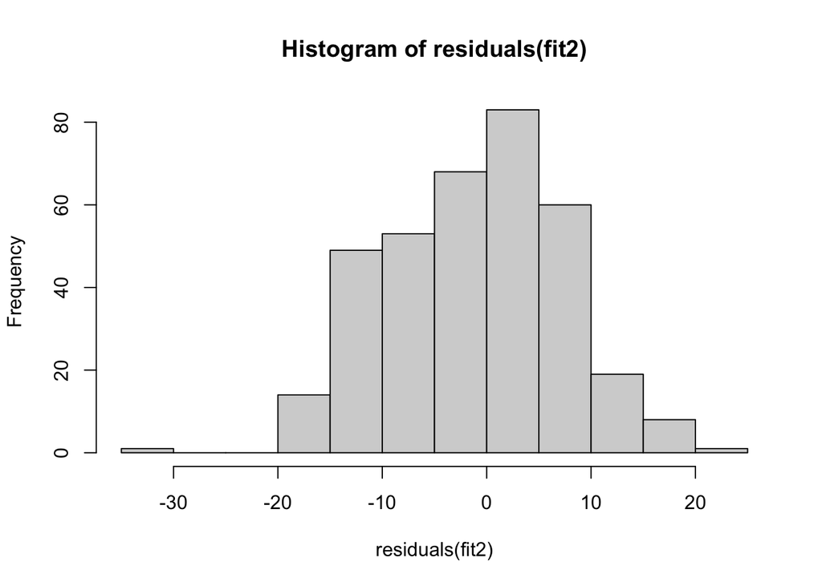

```r
# このモデルでMPの影響を除いたときの分布がポアソン分布になっているかを確認する
hist(residuals(fit2))
```

# 3 POS入りのモデルと、なしのモデルを比較する検定

帰無仮説：pos入りじゃないモデル 対立仮説：pos入りのモデル

```r
# 検定(帰無仮説 - 対立仮説)
fit1$deviance - fit2$deviance
```

```
## [1] 835.0964
```

```r
data$y.rnd <- rpois(nrow(data), lambda = mean(data$PTS))

fit1_rnd <- glm(y.rnd ~ MP, data = data, family = poisson)
fit2_rnd <- glm(y.rnd ~ MP + pos, data = data, family = poisson)

fit1_rnd$deviance - fit2_rnd$deviance
```

```
## [1] 4.198016
```

```r
get.dd <- function(data){
    n.sample <- nrow(data)
    y.mean <- mean(data$PTS)
    data$y.rnd <- rpois(n.sample, lambda = y.mean)
    fit1_rnd <- glm(y.rnd ~ MP, data = data, family = poisson)
    fit2_rnd <- glm(y.rnd ~ MP + pos, data = data, family = poisson)
    fit1_rnd$deviance - fit2_rnd$deviance
}

pb <- function(d, n.bootstrap){
    replicate(n.bootstrap, get.dd(d))
}

dd12 <- pb(data, n.bootstrap = 1000)

summary(dd12)
```

```
##    Min. 1st Qu.  Median    Mean 3rd Qu.    Max.
##  0.1318  2.0041  3.4535  3.9097  5.0021 20.9546
```

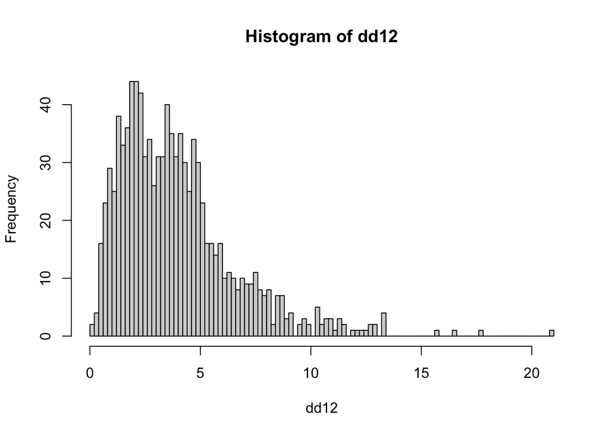

```r
hist(dd12, 100)
```

```r
anova(fit1, fit2, test = 'Chisq')
```

```
## Analysis of Deviance Table
##
## Model 1: PTS ~ MP
## Model 2: PTS ~ MP + pos
##   Resid. Df Resid. Dev Df Deviance  Pr(>Chi)
## 1       354      26372
## 2       350      25537  4    835.1 < 2.2e-16 ***
## ---
## Signif. codes:  0 '***' 0.001 '**' 0.01 '*' 0.05 '.' 0.1 ' ' 1
```